# SEATRAC Introduction to R: Session 1

# Getting help

To get more information on a function, use the ? operator. This brings up a help page describing how the function works. These pages can be pretty dense and technical, even for longtime R users, so don’t be discouraged if it’s hard to understand

```r
?t.test()
```

To see an example of how a function is used, try the ‘example’ function. Not every function has examples though!

```r
example(t.test)
```

```
##
## t.test> ## Two-sample t-test
## t.test> t.test(1:10, y = c(7:20))      # P = .00001855
##
##  Welch Two Sample t-test
##
## data:  1:10 and c(7:20)
## t = -5.4349, df = 21.982, p-value = 1.855e-05
## alternative hypothesis: true difference in means is not equal to 0
## 95 percent confidence interval:
##  -11.052802  -4.947198
## sample estimates:
## mean of x mean of y
##       5.5      13.5
##
##
## t.test> t.test(1:10, y = c(7:20, 200)) # P = .1245    -- NOT significant anymore
##
##  Welch Two Sample t-test
##
## data:  1:10 and c(7:20, 200)
## t = -1.6329, df = 14.165, p-value = 0.1245
## alternative hypothesis: true difference in means is not equal to 0
## 95 percent confidence interval:
##  -47.242900   6.376233
## sample estimates:
## mean of x mean of y
##   5.50000  25.93333
##
##
## t.test> ## Traditional interface
## t.test> with(mtcars, t.test(mpg[am == 0], mpg[am == 1]))
##
##  Welch Two Sample t-test
##
## data:  mpg[am == 0] and mpg[am == 1]
## t = -3.7671, df = 18.332, p-value = 0.001374
## alternative hypothesis: true difference in means is not equal to 0
## 95 percent confidence interval:
##  -11.280194  -3.209684
```

[output cut: 69 more lines]

```
##
##
## t.test> ## Formula interface
## t.test> t.test(Pair(extra.1, extra.2) ~ 1, data = sleep2)
##
##  Paired t-test
##
## data:  Pair(extra.1, extra.2)
## t = -4.0621, df = 9, p-value = 0.002833
## alternative hypothesis: true mean difference is not equal to 0
## 95 percent confidence interval:
##  -2.4598858 -0.7001142
## sample estimates:
## mean difference
##           -1.58
```

Note: Searching with a specific question will also return many useful tutorials online.

### Bonus example: a Linear Model

In this example, we’re going to apply linear regression analysis to test the statistical association of BMI with different other patient factors.

Clinical data are often analyzed by linear regression analyses. In R, the command to perform an ordinary least squares linear model is `lm()`. The `summary()` function reports several result outputs from the linear model.

```r
IndepVar = data$BMI
FactorGender = as.factor(data$Gender)
FactorSmoking = as.factor(data$Smoking)
FactorExercise = as.factor(data$`Exercise Habits`)

BMImodel = lm(IndepVar ~ FactorGender + FactorSmoking + FactorExercise)

summary(BMImodel)
```

```
##
## Call:
## lm(formula = IndepVar ~ FactorGender + FactorSmoking + FactorExercise)
##
## Residuals:
##      Min       1Q   Median       3Q      Max
## -10.5329  -5.4201   0.4577   5.0570  10.1465
##
## Coefficients:
##                      Estimate Std. Error t value Pr(>|t|)
## (Intercept)           29.0192     1.3219  21.953   <2e-16 ***
## FactorGenderMale      -1.0615     1.2075  -0.879    0.382
## FactorSmokingYes       1.7193     1.2379   1.389    0.168
## FactorExerciseLow     -0.9906     1.4822  -0.668    0.506
## FactorExerciseMedium  -0.4433     1.4861  -0.298    0.766
## ---
## Signif. codes:  0 '***' 0.001 '**' 0.01 '*' 0.05 '.' 0.1 ' ' 1
##
## Residual standard error: 6.002 on 95 degrees of freedom
## Multiple R-squared:  0.03109,    Adjusted R-squared:  -0.009709
## F-statistic: 0.762 on 4 and 95 DF,  p-value: 0.5526
```

To see more functionality associated with the `lm` function, we can see the example report:

```r
example(lm)
```

```
##
## lm> require(graphics)
##
## lm> ## Annette Dobson (1990) "An Introduction to Generalized Linear Models".
## lm> ## Page 9: Plant Weight Data.
## lm> ctl <- c(4.17,5.58,5.18,6.11,4.50,4.61,5.17,4.53,5.33,5.14)
##
## lm> trt <- c(4.81,4.17,4.41,3.59,5.87,3.83,6.03,4.89,4.32,4.69)
##
## lm> group <- gl(2, 10, 20, labels = c("Ctl","Trt"))
##
## lm> weight <- c(ctl, trt)
##
## lm> lm.D9 <- lm(weight ~ group)
##
## lm> lm.D90 <- lm(weight ~ group - 1) # omitting intercept
##
## lm> ## No test:
## lm> ##D anova(lm.D9)
## lm> ##D summary(lm.D90)
## lm> ## End(No test)
## lm> opar <- par(mfrow = c(2,2), oma = c(0, 0, 1.1, 0))
##
## lm> plot(lm.D9, las = 1)      # Residuals, Fitted, ...
```

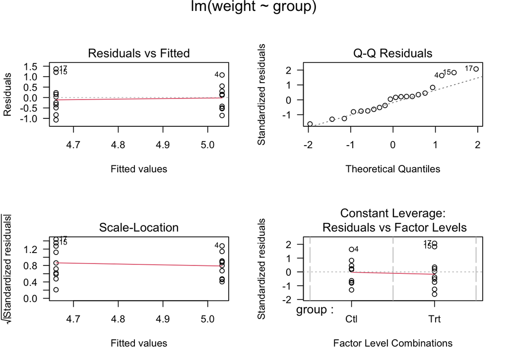

```
##
## lm> par(opar)
##
## lm> ## Don't show:
## lm> ## model frame :
## lm> stopifnot(identical(lm(weight ~ group, method = "model.frame"),
## lm+                     model.frame(lm.D9)))
##
## lm> ## End(Don't show)
## lm> ### less simple examples in "See Also" above
## lm>
## lm>
## lm>
```